# 9.3 - Modelos autorregresivos para series temporales

## Ejemplo: MA(2)

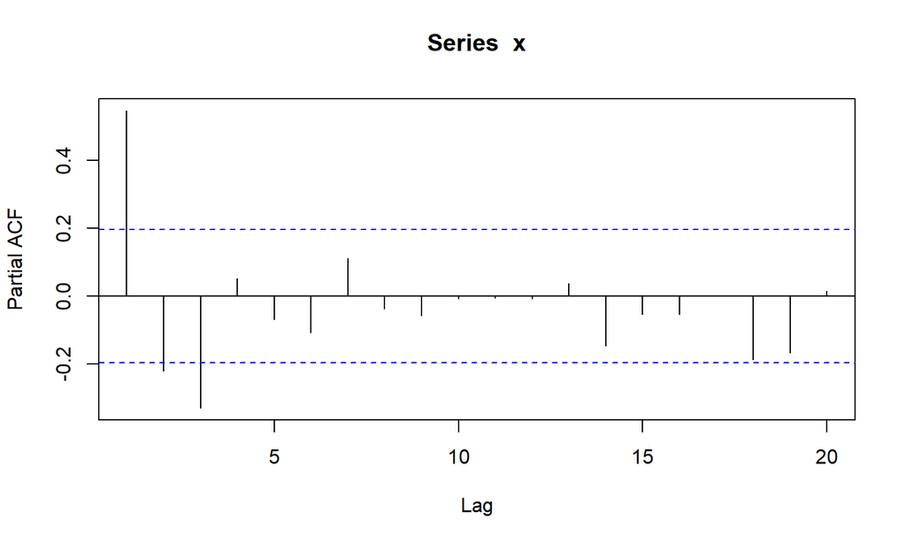

```r
pacf(x)  # Los coeficientes decaen exponencialmente para retardos cada vez mayores
```

## Estimación de un modelo MA

```r
x_mamod = arima(x, order = c(0, 0, 2))  ## Orden c(0, 0, q)
x_mamod
```

```
##
## Call:
## arima(x = x, order = c(0, 0, 2))
##
## Coefficients:
##          ma1     ma2  intercept
##       0.7177  0.5386     0.2388
## s.e.  0.0905  0.0934     0.2000
##
## sigma^2 estimated as 0.7983:  log likelihood = -131.09,  aic = 270.19
```

## Modelos ARMA(p, q)

- Una forma muy conveniente de combinar las propiedades de los dos modelos vistos hasta ahora consiste en crear un modelo ARMA, como suma de las dos componentes de un modelo AR(p) y uno MA(q), respectivamente:

\[x_t = \alpha_1x_{t-1} + \alpha_2x_{t-2} + \ldots + \alpha_px_{t-p}+w_t + \beta_1 w_{t-1} + \beta_2 w_{t-2} + \ldots + \beta_n w_{t-q}\]

- Igual que en los modelos AR, el proceso es **estacionario** si \(|\alpha_i| < 1\).
- El modelo AR(p) es un caso particular, ARMA(p, 0).
- El modelo MA(q) es un caso particular, ARMA(0, q).
- Los modelos ARMA nos ofrecen **parsimonia** respecto al número de parámetros necesarios para explicar la serie de los datos (menor que un solo modelo AR o MA).

## Ejemplo ARMA

- Podemos generar procesos ARMA mediante la función `arima.sim`.
- La función `arima` ajusta un modelo ARMA siempre que pasemos como vector de orden `c(p, 0, q)`.

```r
set.seed(1)
x = arima.sim(n = 1000, list(ar = -0.6, ma = 0.5))
coef(arima(x, order = c(1, 0, 1)))
```

```
##         ar1         ma1   intercept
## -0.32256073  0.18742515 -0.01608392
```

## Modelos ARIMA

- Muchas series temporales no son estacionarias, puesto que incluyen efectos estacionales o tendencias que les hacen incumplir las condiciones necesarias, incluso para estacionariedad débil.
- Sin embargo, en muchas ocasiones ocurre que al **diferenciar** (restar) una serie temporal respecto de una versión retardada de la misma serie (o varias con diferentes retardos cada una), obtenemos como resulado una **serie estacionaria**, sobre la que sí podemos aplicar los modelos vistos hasta el momento.
- Como para recuperar la serie original debemos agregar o **integrar** las series diferenciadas, estos modelos reciben el nombre de autorregresivos integrados de media móvil (ARIMA).
- Existen además extensiones particulares de estos modelos, como los modelos ARIMA estacionales (SARIMA), que permiten además incluir efectos de cambios repetitivos en periodos concretos de la serie.
- La metodología para modelar y resolver este tipo de modelos generales es la que demos a Box y Jenkins [Box y Jenkins 2015].

## Definición de proceso ARIMA

- Una serie temporal \(\{x_t\}\) se dice que es **integrada de orden d**, denotado como \(I(d)\), si la d-ésima diferencia de \(\{x_t\}\) es un proceso estacionario (ruido blanco).
- Por tanto, una serie \(\{x_t\}\) sigue un proceso ARIMA(p, d, q) si la d-ésima diferencia de la serie temporal sigue un proceso ARMA(p, q)
- El paseo aleatorio es un caso especial de serie I(1). Si diferenciamos la serie respecto de su versión retardada un intervalo, por definición obtenemos como resultado ruido blanco, un proceso estacionario.

## Ejemplo: producción eléctrica en Australia

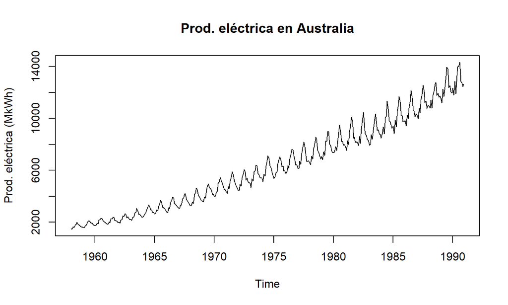

```r
link = "http://www.maths.adelaide.edu.au/andrew.metcalfe/Data/cbe.dat"
cbe = read.table(link, header = T)
elec_ts = ts(cbe[,3], start=1958, freq=12)
plot(elec_ts, ylab="Prod. eléctrica (MkWh)", main="Prod. eléctrica en Australia")
```

## Ejemplo: producción eléctrica en Australia

- El comando `diff(ts, d=2)` obtendría la diferencia de orden 2 de una serie.

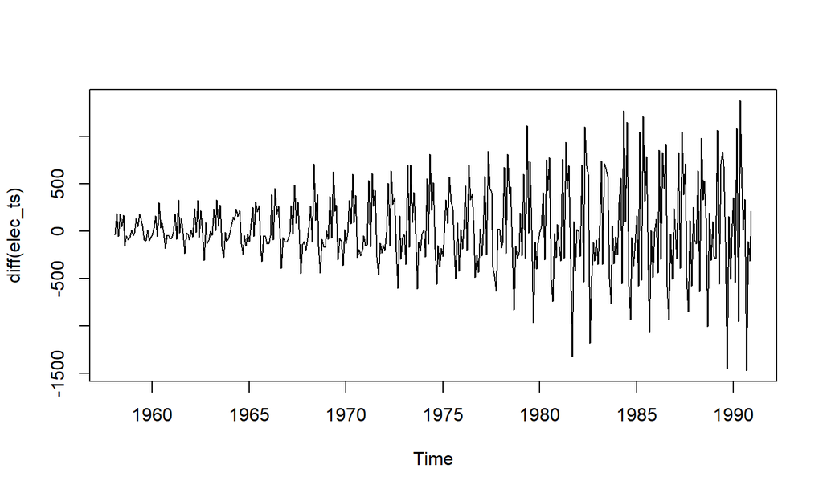

```r
plot(diff(elec_ts))
```

## Ejemplo: producción eléctrica en Australia

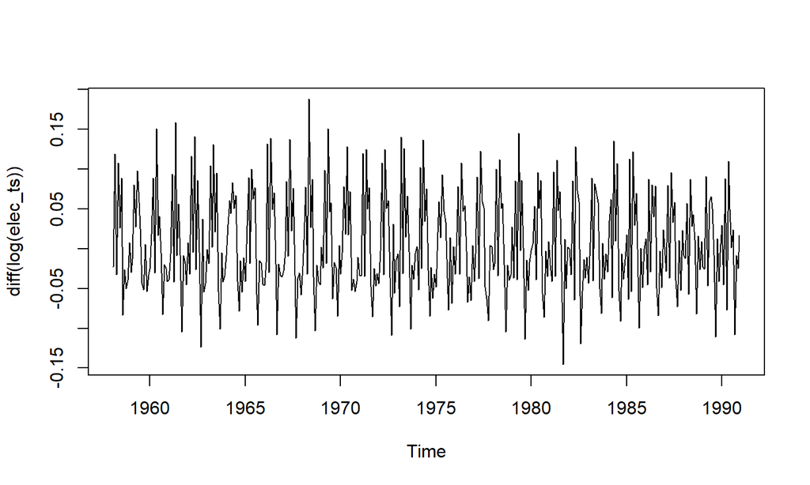

```r
plot(diff(log(elec_ts)))
```

## Ejemplo: predicción prod. elec. Australia

- Usamos las funciones `auto.arima()` y `forecast()` del paquete `forecast` de R.
- Para más información: https://otexts.com/fpp2/arima-r.html.

```r
# Detecta componentes ARIMA y también estacionales (modelo SARIMA)
arima_elec_ts <- log(elec_ts) %>% auto.arima
arima_elec_ts
```

```
## Series: .
## ARIMA(2,1,1)(2,1,2)[12]
##
## Coefficients:
##          ar1     ar2      ma1     sar1    sar2     sma1     sma2
##       0.1484  0.1216  -0.7888  -0.4863  0.0219  -0.1150  -0.4971
## s.e.  0.1188  0.0887   0.0953   0.2780  0.0998   0.2728   0.2234
##
## sigma^2 estimated as 0.0004251:  log likelihood=942.85
## AIC=-1869.71   AICc=-1869.32   BIC=-1838.12
```

## Ejemplo: predicción prod. elec. Australia

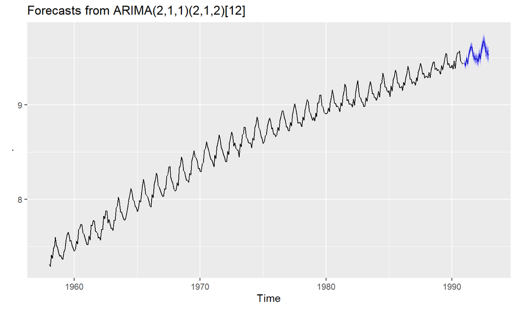

```r
# Detecta componentes ARIMA y también estacionales (modelo SARIMA)
arima_elec_ts %>% forecast %>% autoplot
```

## Simulación ARIMA

- [Video de ejemplo de series ARIMA simuladas](http://ellisp.github.io/blog/2015/11/21/arima-sims)
- Primera fila: ruido blanco; proceso autorregresivo de orden uno con parámetro \(ar1 = 0.8\).
- Segunda fila: proceso de media móvil con parámetro \(ma1 = 0.8\), proceso ARMA(1,1) que combina los dos anteriores.
- Tercera fila: modelo ARIMA(1, 1, 1); ARIMA(2, 2, 2) con parámetros extra y con una suma (integración) adicional.

## Otros modelos avanzados

- Modelos SARIMA: Tienen en cuenta explícitamente tendencias estacionales para cada una de las componentes del modelo ARIMA (AR, MA). Mejora las predicciones en series con efectos estacionales acusados (e.g. procesos sociales, ecológicos, etc.).
- Modelos ARCH y GARCH: son modelos generados para series con **heterocedasticidad condicionada**, es decir, para series temporales cuya varianza no es constante a lo largo del tiempo, sino que varía en diferentes periodos. Muy empleados en análisis de series financieras con gran volatilidad de valores.
- Modelos VAR y VARMA: permiten el modelado multivariante de varias series temporales estudiadas conjuntamente.
  - En este caso, las series deben ser **cointegradas**, es decir, deben compartir una tendencia estocástica común.
  - Existen métodos estadísticos para detectar situaciones de cointegración entre varias series temporales.

## Referencias

- George E. P. Box, Gwilym M. Jenkins,Gregory C. Reinsel, Greta M. Ljung. *Time Series Analysis: Forecasting and Control*. Wiley Series in Probability and Statistics,
- Wayne A. Woodward, Henry L. Gray, Alan C. Eliott. Applied Time Series Analysis with R. CRC Press, 2017.
- Hyndman, R.J., & Athanasopoulos, G. (2018) Forecasting: principles and practice, 2nd edition, OTexts: Melbourne, Australia. OTexts.com/fpp2. Accessed on 11-04-2019. URL: https://otexts.com/fpp2/.
- Seminario FPP2: https://robjhyndman.com/seminars/nyc2018/.
- Robert H. Shumway, David S. Stoffer. Time Series Analysis and Applications. EZ Edition, with R Examples. Abril, 2016. [PDF](http://www.stat.pitt.edu/stoffer/tsa3/tsa3EZ.pdf).
- Paul S. P. Cowpertwait, Andrew V. Metcalfe. Introductory Time Series with R. Springer, 2009.
- Jonathan D. Cryer, Kung-Sik Chang. Time Series Anlaysis With Applications in R. Springer, 2008.
- Daniel Peña. Análisis de series temporales. Ciencias Sociales. Alianza Editorial. 2005.